# US College Ranking Analysis

Moni Nguyen

2023-07-07

Let read some data:

```r
df <- read.csv("C:/Users/nguye/Downloads/2022 US College Rankings.csv")
```

Let take a quick look at the data set:

```r
head(df)
```

```
##                            College.Name Adjusted.Rank Tuition
## 1                  Princeton University             1   56010
## 2                   Columbia University             2   63530
## 3                    Harvard University             2   55587
## 4 Massachusetts Institute of Technology             2   55878
## 5                       Yale University             5   59950
## 6                   Stanford University             6   56169
##   Enrollment.Numbers
## 1               4773
## 2               6170
## 3               5222
## 4               4361
## 5               4703
## 6               6366
```

Let find out if the data set have any missing value:

```r
num_missing_college.name <- sum(is.na(df$College.Name))
print(num_missing_college.name)
```

```
## [1] 0
```

```r
num_missing_rank <- sum(is.na(df$Adjusted.Rank))
print(num_missing_rank)
```

```
## [1] 0
```

```r
num_missing_tuition <- sum(is.na(df$Tuition))
print(num_missing_tuition)
```

```
## [1] 0
```

```r
num_missing_enrollment <- sum(is.na(df$Enrollment.Numbers))
print(num_missing_enrollment)
```

```
## [1] 0
```

Hence, there are no missing values.

Here is the summary of the data:

```r
summary(df)
```

```
##  College.Name       Adjusted.Rank       Tuition      Enrollment.Numbers
##  Length:161         Min.   :  1.00   Min.   : 6120   Min.   :  901
##  Class :character   1st Qu.: 38.00   1st Qu.:33928   1st Qu.: 6114
##  Mode  :character   Median : 79.00   Median :44196   Median :11612
##                     Mean   : 77.96   Mean   :44110   Mean   :16057
##                     3rd Qu.:117.00   3rd Qu.:55776   3rd Qu.:24505
##                     Max.   :148.00   Max.   :63530   Max.   :63124
```

The top 5 highest ranked college and the top 5 lowest ranked:

```r
asc_ranked <- head(df[order(df$Adjusted.Rank),],5)
print(asc_ranked)
```

```
##                            College.Name Adjusted.Rank Tuition
## 1                  Princeton University             1   56010
## 2                   Columbia University             2   63530
## 3                    Harvard University             2   55587
## 4 Massachusetts Institute of Technology             2   55878
## 5                       Yale University             5   59950
##   Enrollment.Numbers
## 1               4773
## 2               6170
## 3               5222
## 4               4361
## 5               4703
```

```r
desc_ranked <- head(df[order(-df$Adjusted.Rank),],5)
print(desc_ranked)
```

```
##                          College.Name Adjusted.Rank Tuition Enrollment.Numbers
## 148         Colorado State University           148   31540              25186
## 149                CUNY--City College           148   19010              12587
## 150               Duquesne University           148   43526               5383
## 151           George Mason University           148   36579              27105
## 152 Michigan Technological University           148   38112               5642
```

The college with the highest, median and lowest tuition are:

```r
highest_tuition <- df$College.Name[which.max(df$Tuition)]
college_median <- df$College.Name[df$Tuition == median(df$Tuition)]
lowest_tuition <- df$College.Name[which.min(df$Tuition)]

print(highest_tuition)
```

```
## [1] "Columbia University"
```

```r
print(college_median)
```

```
## [1] "University of California--Santa Barbara"
```

```r
print(lowest_tuition)
```

```
## [1] "Brigham Young University--Provo"
```

The college with the highest, median and lowest enrollment are:

```r
highest_enrollment <- df$College.Name[which.max(df$Enrollment.Numbers)]
median_enrollment <- df$College.Name[df$Enrollment.Numbers == median(df$Enrollment.Numbers)]
lowest_enrollment <- df$College.Name[which.min(df$Enrollment.Numbers)]

print(highest_enrollment)
```

```
## [1] "Arizona State University"
```

```r
print(median_enrollment)
```

```
## [1] "Loyola University Chicago"
```

```r
print(lowest_enrollment)
```

```
## [1] "California Institute of Technology"
```

The correlation between tuition and enrollment:

```r
correlation <- cor(df$Tuition,df$Enrollment.Numbers)
print(correlation)
```

```
## [1] -0.5558214
```

Interpreting the correlation coefficient:

The negative sign indicates an inverse relationship, meaning that as tuition increases, enrollment tends to decrease, and vice versa.

Conclusions:

Colleges with higher tuition fees tend to have lower enrollment numbers.As tuition increases, the demand for enrollment may decrease, possibly due to affordability concerns.However, it’s important to note that correlation does not imply causation. Other factors not considered in the analysis could influence enrollment numbers.

Let install the ggplot2 for visualization:

```r
library(ggplot2)
```

Let create a scatter plot for the correlation between tuition and enrollment:

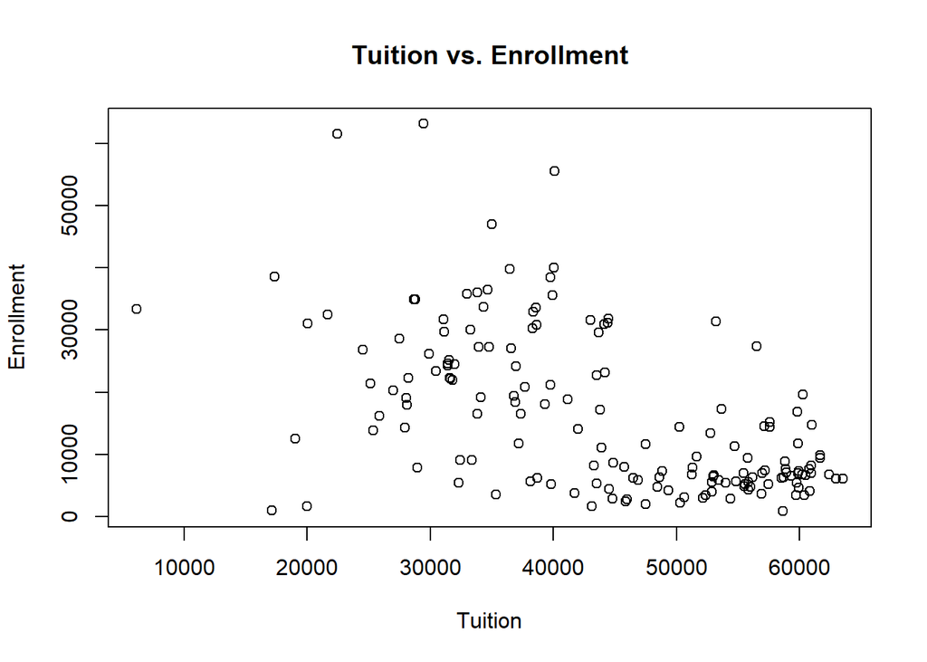

```r
plot(df$Tuition, df$Enrollment.Numbers,xlab = "Tuition",ylab = "Enrollment",main = "Tuition vs. Enrollment")
```

By observing the scatter plot, we can draw the conclusion that tuition is not an ultimate factor that influence enrollment number but it can be other factors such as reputation, scholarship and location.